# HW04 Part 1: Complete Chapter 3

Afreen Alam

12 July 2020

## Chapter 3

- Change “your name” in the YAML header above to your name.

### Section 3.1

Load the tidyverse packages. I’ve entered the first code chunk for you. **You must enter all subsequent code chunks and run the code.**

```r
library("tidyverse")
```

If you get an error, then you did not install the `tidyverse` package like you were supposed to in the previous assignment. Go back to that assignment and complete that step. (This should not be the case, though.)

### Section 3.2: First steps

Enter your code chunks for Section 3.2 here.

Get in the habit of entering a brief description of what each chunk of code does. Enter this above the chunk, like I did in Section 3.1.

View data from mpg

```r
mpg
```

| manufacturer | model | displ | year | cyl | trans | drv | cty | hwy | fl | class |
| --- | --- | --- | --- | --- | --- | --- | --- | --- | --- | --- |
| audi | a4 | 1.8 | 1999 | 4 | auto(l5) | f | 18 | 29 | p | compact |
| audi | a4 | 1.8 | 1999 | 4 | manual(m5) | f | 21 | 29 | p | compact |
| audi | a4 | 2.0 | 2008 | 4 | manual(m6) | f | 20 | 31 | p | compact |
| audi | a4 | 2.0 | 2008 | 4 | auto(av) | f | 21 | 30 | p | compact |
| audi | a4 | 2.8 | 1999 | 6 | auto(l5) | f | 16 | 26 | p | compact |
| audi | a4 | 2.8 | 1999 | 6 | manual(m5) | f | 18 | 26 | p | compact |
| audi | a4 | 3.1 | 2008 | 6 | auto(av) | f | 18 | 27 | p | compact |
| audi | a4 quattro | 1.8 | 1999 | 4 | manual(m5) | 4 | 18 | 26 | p | compact |
| audi | a4 quattro | 1.8 | 1999 | 4 | auto(l5) | 4 | 16 | 25 | p | compact |
| audi | a4 quattro | 2.0 | 2008 | 4 | manual(m6) | 4 | 20 | 28 | p | compact |

[output cut: 224 more lines]

Plot displ on the x-axis and hwy on the y-axis

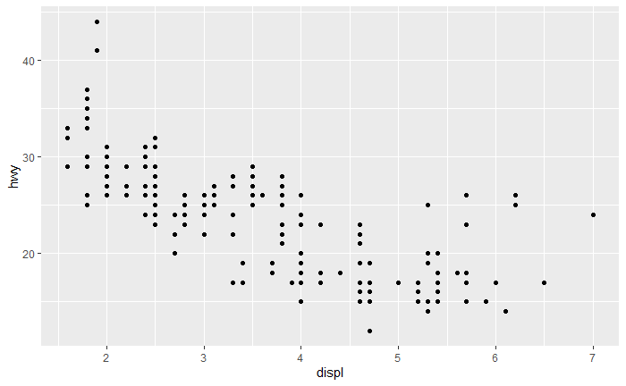

```r
ggplot(data = mpg) +
  geom_point(mapping = aes(x = displ, y = hwy))
```

#### Section 3.2 Questions

Answer the questions *completely.* Some answers will require you to write code in a code chunk and also to type text before or after the chunk. Other answers will require only code or only text.

**1:** Run ggplot(data = mpg). What do you see?

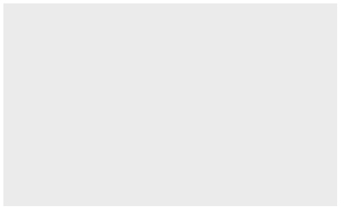

```r
ggplot(data = mpg)
```

This creates an empty graph (a coordinate system).

**2:** How many rows are in `mpg`? How many columns? **Hint:** Use the `dim()` function. Type `dim()` in the console to learn what `dim()` does.

```r
dim(mpg)
```

```
[1] 234  11
```

There are 234 rows and 11 columns in ‘mpg’.

**3:** What does the `drv` variable describe? Read the help for `?mpg` to find out.

It describes the type of drive train, where f = front-wheel drive, r = rear wheel drive, 4 = 4wd

**4:** Make a scatterplot of `hwy` vs `cyl`.

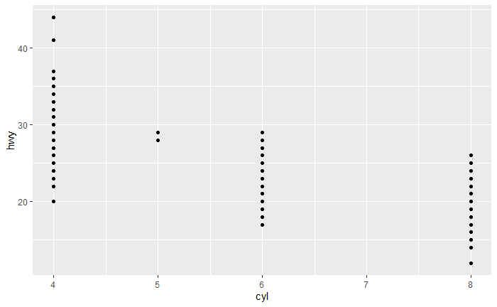

```r
ggplot(data = mpg) +
  geom_point(mapping = aes(x = cyl, y = hwy))
```

**5:** What happens if you make a scatterplot of `class` vs `drv`? Why is the plot not useful?

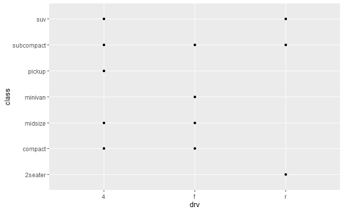

```r
ggplot(data = mpg) +
  geom_point(mapping = aes(x = drv, y = class))
```

The scatter plot shows the type of drive train each type of car may use. This is not useful as scatter plots are used to show correlation but both variables used have values in levels that are not ordered.(Their data is categorical.)

### Section 3.3: Aesthetic mappings

Assign aesthetic level ‘color’ to class in hwy vs displ scatter plot.

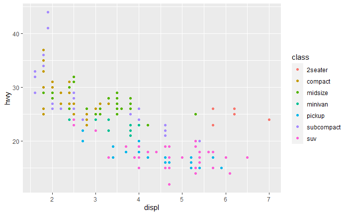

```r
ggplot(data = mpg) +
  geom_point(mapping = aes(x = displ, y = hwy, color = class))
```

Assign aesthetic level ‘size’ to class in hwy vs displ scatter plot.

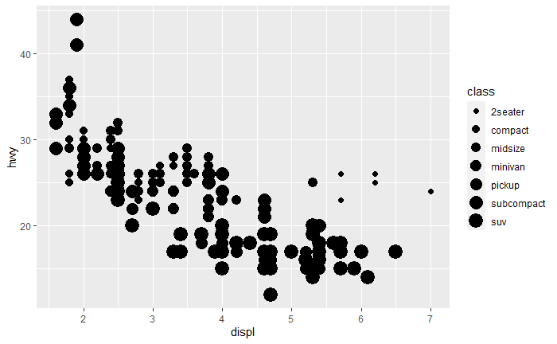

```r
ggplot(data = mpg) +
  geom_point(mapping = aes(x = displ, y = hwy, size = class))
```

On left map ‘class’ to ‘alpha’ aesthetic and on right map ‘class’ to ‘shape’ aesthetic.

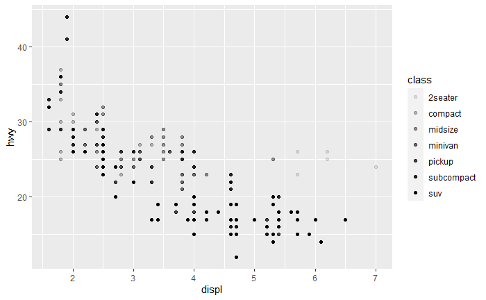

```r
# Left
ggplot(data = mpg) +
  geom_point(mapping = aes(x = displ, y = hwy, alpha = class))
```

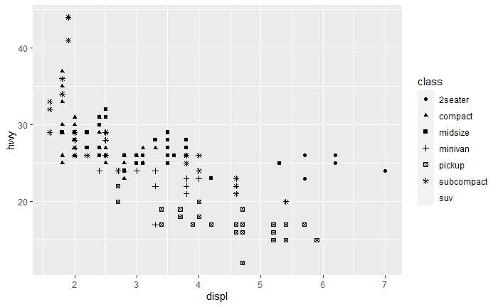

```r
# Right
ggplot(data = mpg) +
  geom_point(mapping = aes(x = displ, y = hwy, shape = class))
```

Make all points in hwy vs displ scatter plot blue.

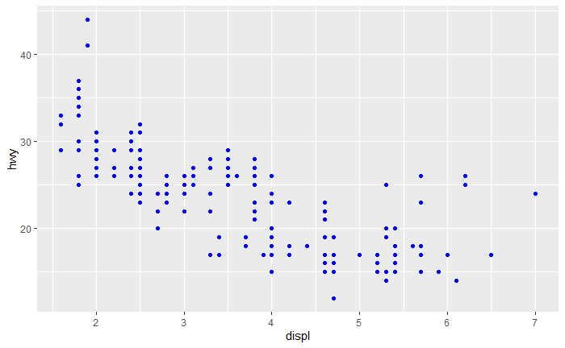

```r
ggplot(data = mpg) +
  geom_point(mapping = aes(x = displ, y = hwy), color = "blue")
```

#### Section 3.3 questions

**1:** What’s gone wrong with this code? Why are the points not blue?

Here the character string “blue” is assigned to all points and shows in default color- red. (If color aesthetic is assigned to variable within mpg it would show more colors assigned to other levels of the variable, here the character string only has one level- itself- so all are one color) The ‘color’ should be outside aes() argument as it is set manually for the points to be blue.

**2:** Which variables in `mpg` are categorical? Which variables are continuous? (*Hint:* type `?mpg` to read the documentation for the dataset). How can you see this information when you run mpg?

By running the following code one can find the required information-

```r
?mpg
```

This opens a tab under Help which describes the variables and the nature of data. The variables with set and limited number of categories/values are called categorical variables. The variables that can have unlimited values are continuous variables. Categorical variables- manufacturer, model, year, cyl, trans, drv, fl, class. Continuous variables- displ, cty, hwy.

**3:** Map a continuous variable to color, size, and shape. How do these aesthetics behave differently for categorical vs. continuous variables? **Note:** You need several code chunks here to answer this question.

Continuous variable- cty (Left)

categorical variable- fl (Right)

# By color

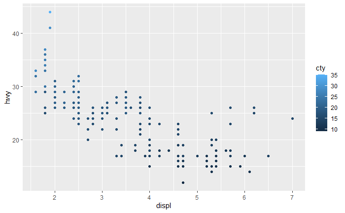

```r
# Left- continuous variable
ggplot(data = mpg) +
  geom_point(mapping = aes(x = displ, y = hwy, color = cty))
```

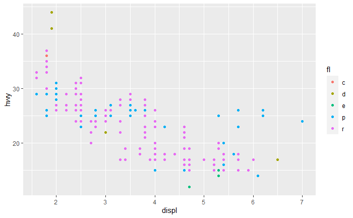

```r
# Right- categorical variable
ggplot(data = mpg) +
  geom_point(mapping = aes(x = displ, y = hwy, color = fl))
```

The continuous variable is assigned colors on a continuous gradient of a single color (depending on order on the scale) whereas categorical variable is assigned distinct colors (unless it is ordered, then it is similar to continuous variable).

# By size

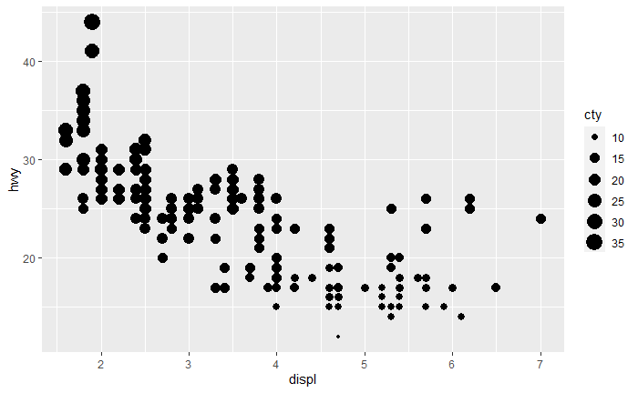

```r
# Left- continuous variable
ggplot(data = mpg) +
  geom_point(mapping = aes(x = displ, y = hwy, size = cty))
```

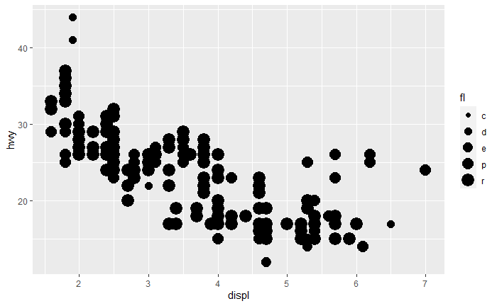

```r
# Right- categorical variable
ggplot(data = mpg) +
  geom_point(mapping = aes(x = displ, y = hwy, size = fl))
```

The legend in continuous variable only gives few landmarks for scale and asks us to approximate the values falling in between whereas, in categorical variable the use of size is advised against, since it is not ordered, and each category is given a dot size (unless it is ordered, then legend similar to continuous variable).

# By shape

```r
# Left- continuous variable
ggplot(data = mpg) +
  geom_point(mapping = aes(x = displ, y = hwy, shape = cty))
```

```
Error: A continuous variable can not be mapped to shape
```

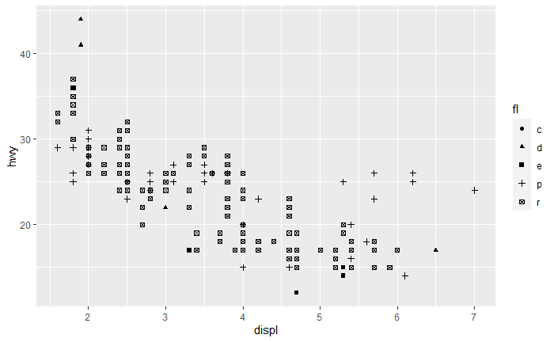

```r
# Right- categorical variable
ggplot(data = mpg) +
  geom_point(mapping = aes(x = displ, y = hwy, shape = fl))
```

The continuous variable plot shows an error because it has way more values that shapes available. The categorical variable shows a plot with different shapes assigned to each category (unless it is ordered like in ‘year’ then it shows an error).

**4:** What happens if you map the same variable to multiple aesthetics?

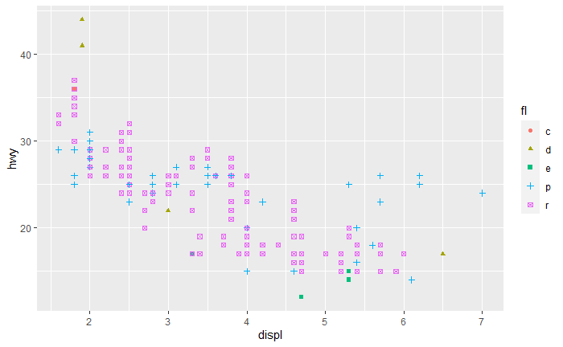

```r
ggplot(data = mpg) +
  geom_point(mapping = aes(x = displ, y = hwy, shape = fl, color = fl))
```

If ggplot is able to make the plot with each aesthetic of the variable individually it will be able to make a plot with both aesthetics of the same variable in one plot.

**5:** What does the stroke aesthetic do? What shapes does it work with? (*Hint:* use `?geom_point`)

Stroke changes the size of the border for shapes (21-25). These are filled shapes in which the color and size of the border can differ from that of the filled interior of the shape.

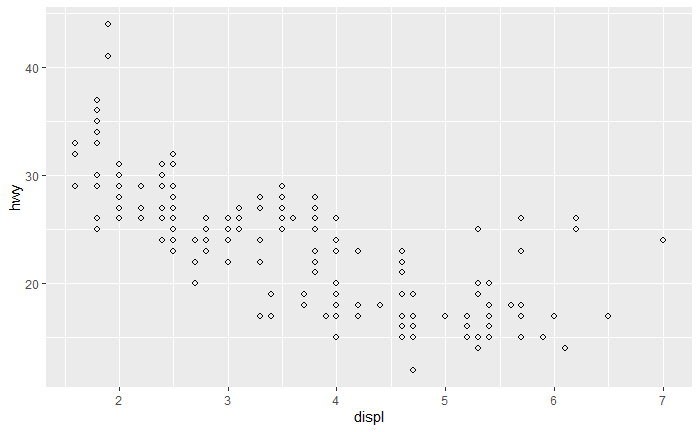

```r
ggplot(data = mpg) +
  geom_point(mapping = aes(x = displ, y = hwy), stroke = 1, shape = 21)
```

**6:** What happens if you map an aesthetic to something other than a variable name, like `aes(colour = displ < 5)`?

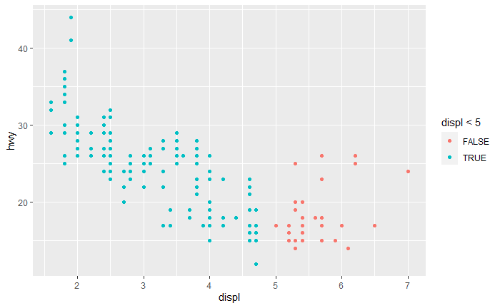

```r
ggplot(data = mpg) +
  geom_point(mapping = aes(x = displ, y = hwy, color = displ < 5))
```

It acts as a logical variable and assigns the points two colors on whether the condition is true or false.

### Section 3.5: Facets

Facet the plot by single discrete variable- ‘class’.

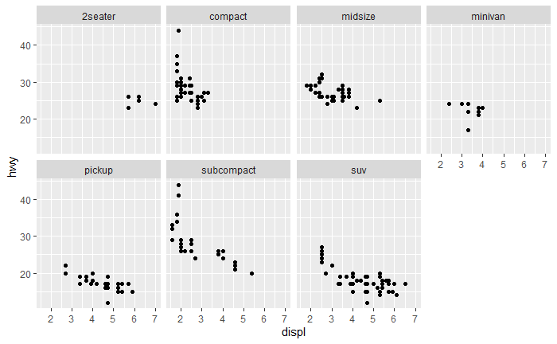

```r
ggplot(data = mpg) +
  geom_point(mapping = aes(x = displ, y = hwy)) +
  facet_wrap(~ class, nrow = 2)
```

Facet the plot using two variables - ‘drv’ and ‘cyl’.

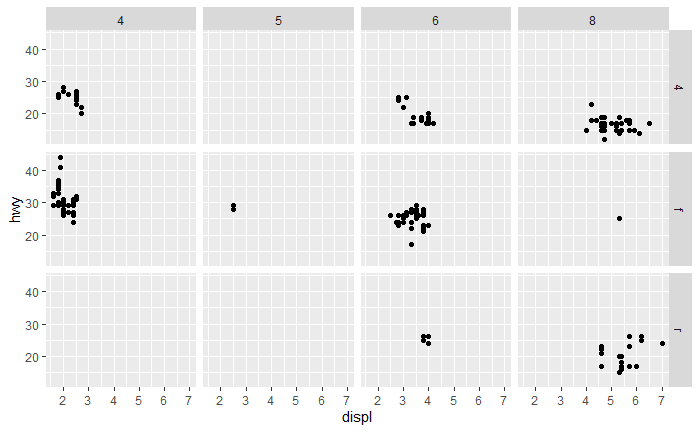

```r
ggplot(data = mpg) +
  geom_point(mapping = aes(x = displ, y = hwy)) +
  facet_grid(drv ~ cyl)
```

#### Section 3.5 questions

**1:** What happens if you facet on a continuous variable? **Note:** Write a prediction, then make and run your code chunk. It would a different plot for each value in the continuous variable.

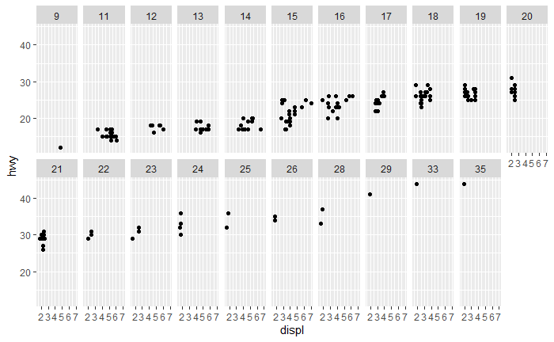

```r
ggplot(data = mpg) +
  geom_point(mapping = aes(x = displ, y = hwy)) +
  facet_wrap(~ cty, nrow = 2)
```

**2:** What do the empty cells in plot with `facet_grid(drv ~ cyl)` mean? How do they relate to this plot? They mean that there is no outcome (point) that satisfies both the conditions of drv and cyl.

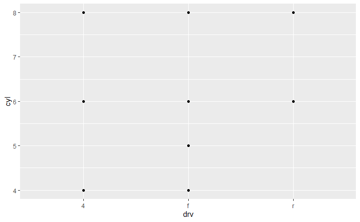

```r
ggplot(data = mpg) +
  geom_point(mapping = aes(x = drv, y = cyl))
```

Unlike the facet_grid plot that breaks plots in all values that the variable acquires, when plotted on cartesian plane the missing 7 cylinders (with 4.5, 5.5,.., 7.5) is also plotted even though under cylinders there is never a 7 recorded. Aside from those rows the intersections where there is no point coincides with the empty plots formed by facet ((cyl,drv): (5,4), (4,r), (5,r)).

**3:** What plots does the following code make? What does `.` do?

They make a hwy vs displ plot facetted by the variable drv and next with cyl.

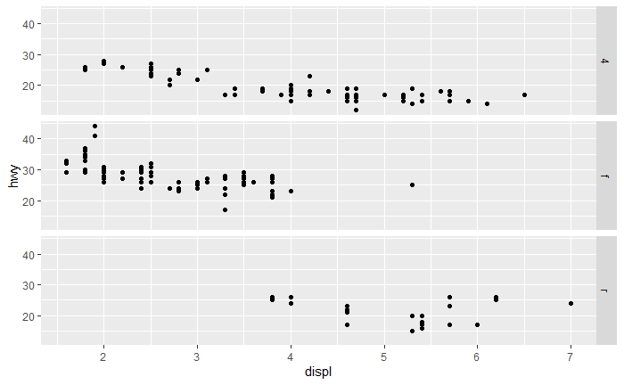

```r
ggplot(data = mpg) +
  geom_point(mapping = aes(x = displ, y = hwy)) +
  facet_grid(drv ~ .)
```

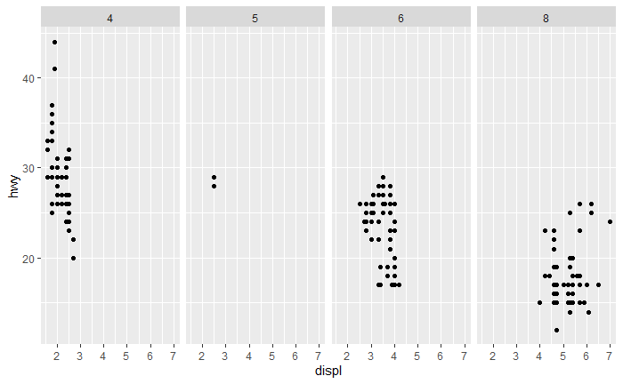

```r
ggplot(data = mpg) +
  geom_point(mapping = aes(x = displ, y = hwy)) +
  facet_grid(. ~ cyl)
```

The ‘.’ after ‘~’ makes all subplots in rows and ‘.’ before ‘~’ makes all subplots in columns dimension.

**4:** Take the first faceted plot below. What are the advantages to using faceting instead of the colour aesthetic? What are the disadvantages? How might the balance change if you had a larger dataset?

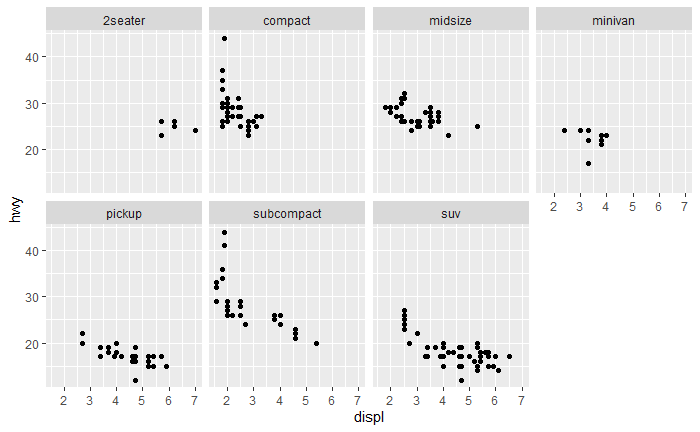

```r
ggplot(data = mpg) +
  geom_point(mapping = aes(x = displ, y = hwy)) +
  facet_wrap(~ class, nrow = 2)
```

Faceting makes it easier to see where the distribution of an individual category lies on the plot. It is hard to see extent of overlap between categories. For a larger dataset facet would be more beneficial as with color aesthetic more number of points on one plot will cause overlapping to occur and with more colors they would become difficult to distinguish from each other.

**5:** Read `?facet_wrap`. What does `nrow` do? What does `ncol` do? What other options control the layout of the individual panels? Why doesn’t `facet_grid()` have nrow and ncol argument?

The ‘nrow’ sets the number of rows the subplots would be arranged in. The ‘ncol’ sets the number of columns the subplots would be arranged in. order of the individual panels may be changed by- ‘dir’ and ‘as.table’. The facet_grid uses two variable. Based on their position before or after ‘~’ it already chooses the number of rows and columns based on levels of variable assigned to each position.

**6:** When using `facet_grid()` you should usually put the variable with more unique levels in the columns. Why?

This is so because the entire plot is rectangular and is longer on the horizontal side. The variable with more levels would get more space to be distributed.

### Section 3.6: Geometric objects

Make two plots- on the left using geom_point and on the right using geom_smooth.

```r
# left
```

[output not shown]

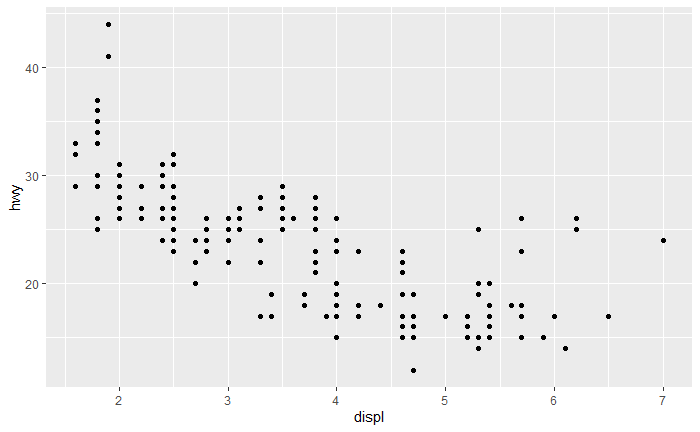

```r
ggplot(data = mpg) +
  geom_point(mapping = aes(x = displ, y = hwy))
```

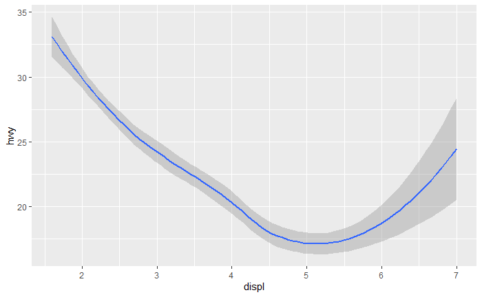

```r
# right
ggplot(data = mpg) +
  geom_smooth(mapping = aes(x = displ, y = hwy))
```

Plot a graph using ‘linetype’ aesthetic for variable ‘drv’.

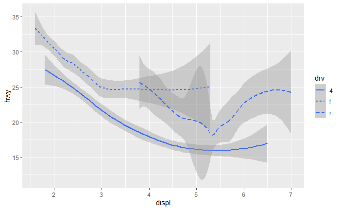

```r
ggplot(data = mpg) +
  geom_smooth(mapping = aes(x = displ, y = hwy, linetype = drv))
```

Make three plots one with just geom_smooth, one with ‘group’ and one with ‘color’. Remember to remove legends.

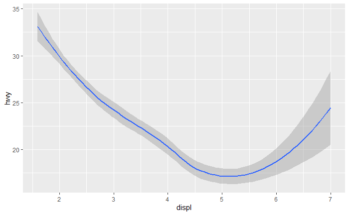

```r
ggplot(data = mpg) +
  geom_smooth(mapping = aes(x = displ, y = hwy))
```

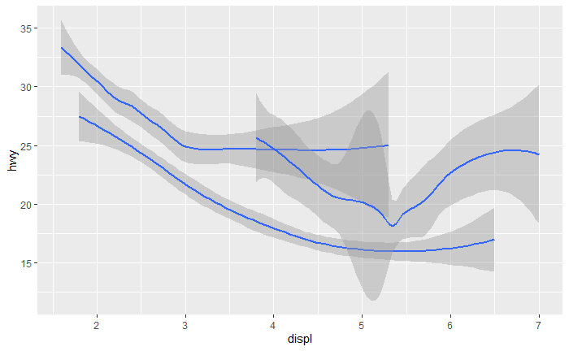

```r
ggplot(data = mpg) +
  geom_smooth(mapping = aes(x = displ, y = hwy, group = drv))
```

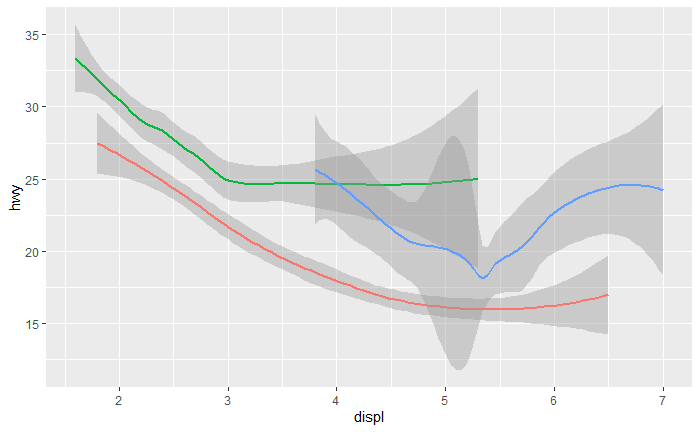

```r
ggplot(data = mpg) +
  geom_smooth(
    mapping = aes(x = displ, y = hwy, color = drv),
    show.legend = FALSE
  )
```

Make a plot that has points and line i.e. using ‘geom_point’ and ‘geom_smooth’.

```r
ggplot(data = mpg) +
  geom_point(mapping = aes(x = displ, y = hwy)) +
  geom_smooth(mapping = aes(x = displ, y = hwy))
```

[output not shown]

Make the previous graph using global mapping

```r
ggplot(data = mpg, mapping = aes(x = displ, y = hwy)) +
  geom_point() +
  geom_smooth()
```

[output not shown]

In the previous map add the aesthetic ‘color’ to the points according to variable ‘class’.

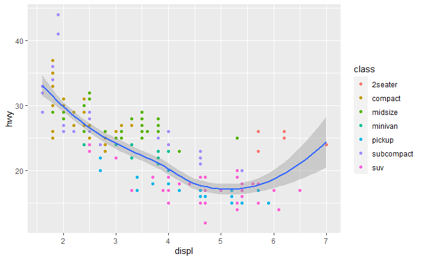

```r
ggplot(data = mpg, mapping = aes(x = displ, y = hwy)) +
  geom_point(mapping = aes(color = class)) +
  geom_smooth()
```

In the above plot make the local data override the global data, select the subcompact cars in geom_smooth

```r
ggplot(data = mpg, mapping = aes(x = displ, y = hwy)) +
  geom_point(mapping = aes(color = class)) +
  geom_smooth(data = filter(mpg, class == "subcompact"), se = FALSE)
```

[output not shown]